# The length of words reflects their conceptual complexity (Supplementary Information)

2016-04-29

This document was created from an [R Markdown file](https://github.com/mllewis/RC/blob/master/analysis/refComplex_paper_analyses_LF.Rmd). All analyses and plots can be reproduced from the [raw data](https://github.com/mllewis/RC/tree/master/data) with the code in this file. This document also contains links to the experimental tasks.

All experimental studies (Studies 1-9 and 11-12) were completed on Amazon Mechanical Turk (AMT). AMT is an online crowdsourcing platform that provides a reliable subject pool for web-based studies [1]. Participants were paid US $0.15-0.30 for their participation, depending on the length of the task.

## Study 1: Geon complexity norms

The task can be found [here](https://mllewis.github.io/projects/RC/experiment34/refcomplex34.html).

Across all experiments, some participants completed more than one study. The results presented here include the data from all participants, but all reported results remain reliable when excluding participants who completed more than one study. Participants were counted as a repeat participant if they completed a study using the same stimuli (e.g., completed both Studies 1 and 2 with geons).

The relationship between number of geons and complexity rating is plotted below (*M* = .47, *SD* = .18). Each point corresponds to an object item (8 per condition). The x-coordinates have been jittered to avoid over-plotting. The confidence intervals are calculated via non-parametric bootstrapping.

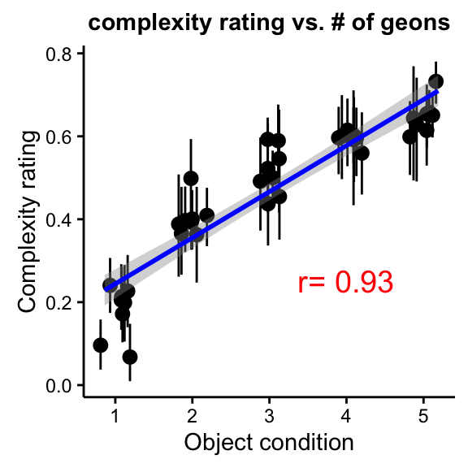

## Study 2: Geon mapping task

The task can be found [here](https://mllewis.github.io/projects/RC/experiment38/refcomplex38.html).

The short word items were: “bugorn,” “ratum,” “lopus,” “wugnum,” “torun,” “gronan,” “ralex,” “vatrus.” The long word items were: “tupabugorn,” “gaburatum,” “fepolopus,” “pakuwugnum,” “mipatorun,” “kibagronan,” “tiburalex,” “binivatrus.”

Plotted below is the effect size (bias to select complex alternative in long vs. short word condition) as a function of the complexity ratio between the two object alternatives. Each point corresponds to an object condition. Conditions are labeled by the quintiles of the two alternatives. For example, the “1/5” condition corresponds to the condition in which one alternative is from the first quintile and the other is from the fifth quintile. In the left plot, complexity is operationalized as the explicit complexity norms (Study 1). On the right, complexity is operationalized in terms of study times (Study 8). Effect sizes were calculated using the log odds ratio [2]. In this and all subsequent plots, errors bars reflect 95% confidence intervals.

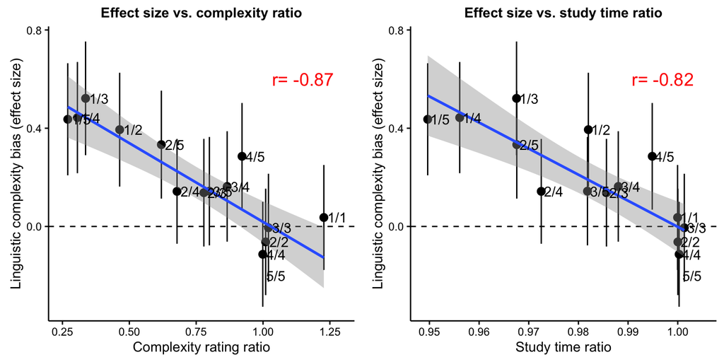

## Study 3: Geon mapping task control

The task can be found [here](https://mllewis.github.io/projects/RC/experiment40/refcomplex40.html).

Plotted below is the proportion complex object selections as a function of the number of syllables in the target label. The dashed line reflects chance selection between the simple and complex alternatives.

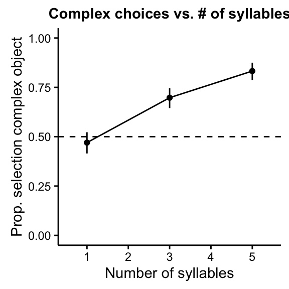

We can compare these conditions to the 1-5 conditions in Experiment 2. There is no evidence that the label type had an effect.

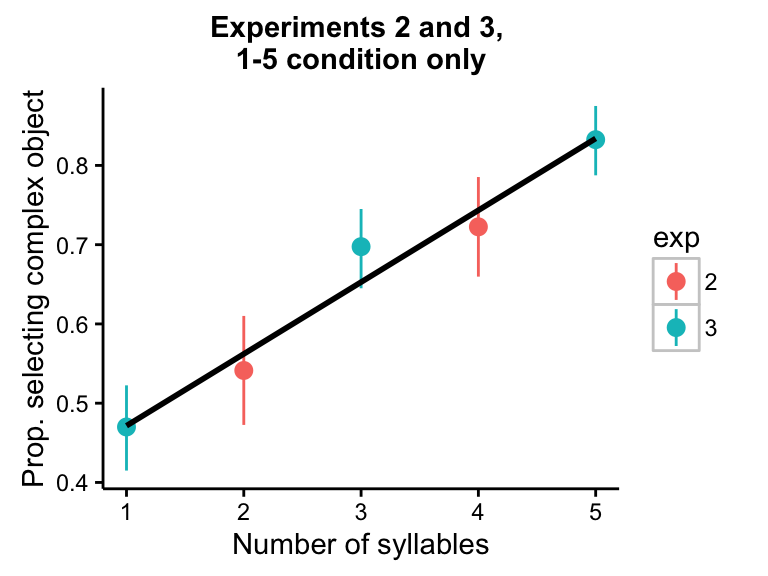

## Study 4: Real object complexity norms

The task can be found [here](http://langcog.stanford.edu/expts/MLL/refComplex/Experiment9/ref_complex_9.html).

Plotted below is the correlation between the two samples (*N* = 60 each, *M1* = .49, *SD1* = .18, *M2* = .44, *SD2* = .18) of complexity norms. Each point corresponds to an object (*n* = 60).

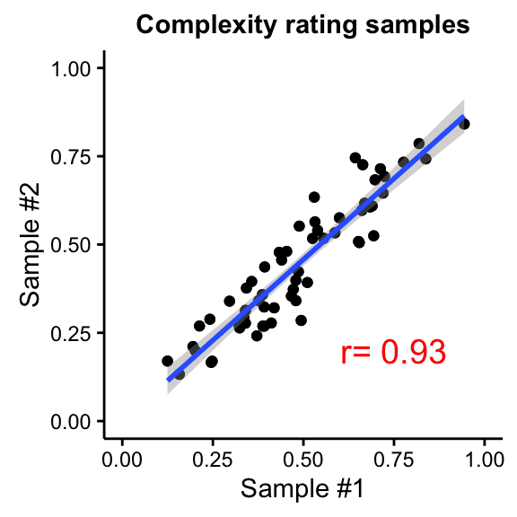

## Study 5: Real object mapping task

The task can be found [here](https://mllewis.github.io/projects/RC/experiment35/refcomplex35.html).

The linguistic items were identical to Study 2.

Plotted below is the effect size (bias to select complex alternative in long vs. short word condition) as a function of the complexity ratio between the two object alternatives. Each point corresponds to an object condition. In the left plot, complexity is operationalized as the explicit complexity norms (Study 4). In the right plot, complexity is operationalized in terms of study times (Study 8).

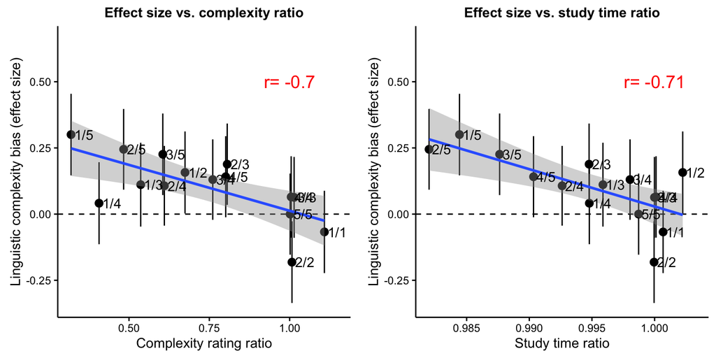

## Study 6: Real object mapping task control

The task can be found [here](https://mllewis.github.io/projects/RC/experiment41/refcomplex41.html).

Plotted below is the proportion of complex object selections as a function of number of syllables. The dashed line reflects chance selection between the simple and complex alternatives.

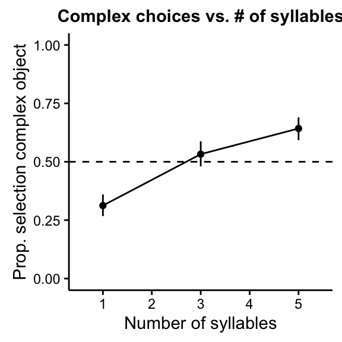

## Study 7: Real object production task

The task can be found [here](https://mllewis.github.io/projects/RC/experiment27/refcomplex27.html).

There were 26 productions (4%) that included more than one word. These productions were excluded.

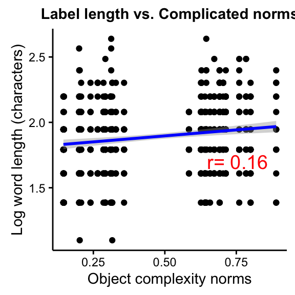

## Study 8a: Geon study time task

The task can be found [here](https://mllewis.github.io/projects/RC/experiment37/refcomplex37.html).

We excluded subjects who performed at or below chance on the memory task (20 or fewer correct out of 40). A response was counted as correct if it was a correct rejection or a hit. This excluded 9 subjects (4%). With these participants excluded, the mean correct was 72%.

Participants were also excluded based on study times. We transformed the time into log space, and excluded responses that were 2 standard deviations above or below the mean. This excluded 4% of responses. Below is a histogram of study times after these exclusions (*M* = 7.40, *SD* = .66). The solid line indicates the mean, and the dashed lines indicate two standard deviations above and below the mean.

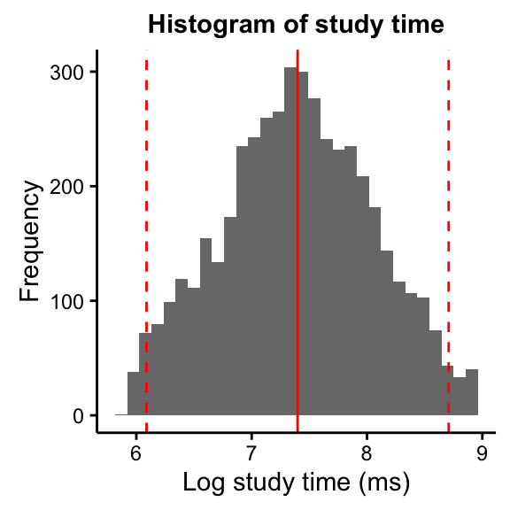

Like for the complexity norms, study times were highly correlated with the number of geons in each object (*r*=.93, *p*<.0001; see plot below, x-coordinates jittered to avoid over-plotting). Objects that contained more geons tended to be studied longer.

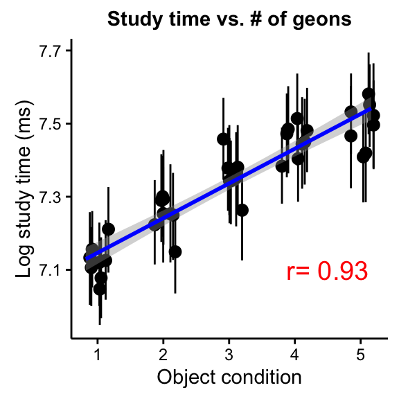

Study times were also highly correlated with complexity norms. Objects that were rated as more complex tended to be studied longer.

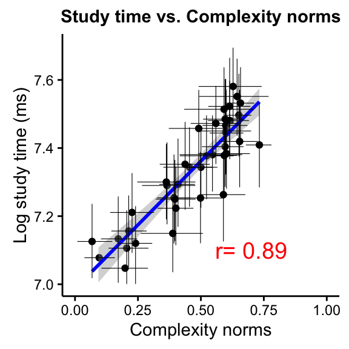

Study times did not predict memory performance. The study times for hits (correct “yes” responses; *M* = 7.33, *SD* = .52) did not differ from misses (correct “no” responses; *M* = 7.34, *SD* = .59; *t*(223) = .61, *p*=.54).

## Study 8b: Real object study time task

The task can be found [here](https://mllewis.github.io/projects/RC/experiment30/refcomplex30.html).

We excluded subjects who performed at or below chance on the memory task (30 or fewer correct out of 60). A response was counted as correct if it was a correct rejection or a hit. This excluded 6 subjects (1%). With these participants excluded, the mean correct was 84%.

```
## [1] "percent correct: 0.84"
```

```
## [1] 1.449619
```

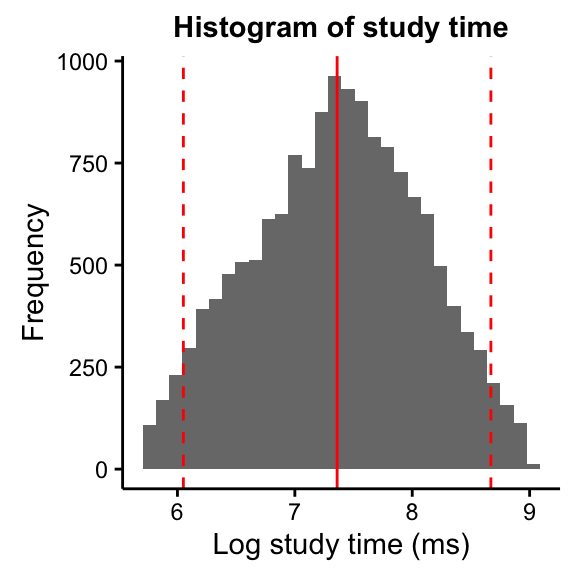

The plot below shows the correlation between study times and explicit complexity norms for each object. Like for the geons, objects that were rated as more complex were studied longer.

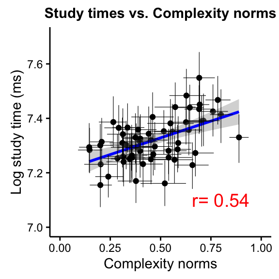

For the real objects, study times predicted memory performance. Study times for hits (correct “yes” responses; *M* = 7.24, *SD* = .60) were greater than for misses (correct “no” responses; *M* = 7.11, *SD* = .66; *t*(393) = 9.74, *p*<.0001).

## Study 9: English complexity norms

The task can be found [here](https://mllewis.github.io/projects/RC/experiment26/refcomplex26.html).

We selected 499 English words that were broadly distributed in their length. All of these words were included in the MRC Psycholinguistic Database [3]. We considered three different metrics of word length: phonemes, syllables, and morphemes. Measures of phonemes and syllables were taken from the MRC corpus and measures of morphemes were taken from CELEX2 database. Below are histograms of the number of words as a function of each of the three length metrics. All three metrics were highly correlated with each other (phonemes and syllables: *r* = .89; phonemes and morphemes: *r* = .65; morphemes and syllables: *r* = .67). All three metrics were also highly correlated with number of characters, the length metric we use for the cross-linguistic analyses in Study 10 (phonemes: *r* = .92; morphemes: *r* = .69; syllables: *r* = .87).

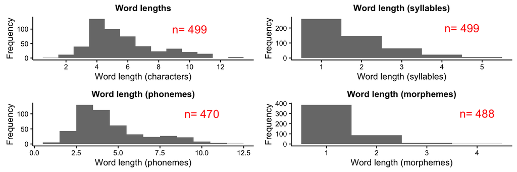

246 participants completed the rating task. We excluded participants who missed a simple math problem in the middle of the task that served as an attentional check. This excluded 6 participants (2%). Complexity ratings (*M* = 3.36, *SD* = 1.93) were highly correlated with length. Below we plot complexity as a function of each of the three length metrics. Each point corresponds to a word. The x-coordinates have been jittered to limit over-plotting.

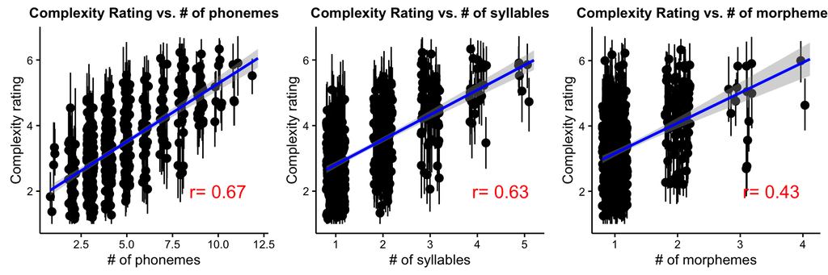

The relationship between length and complexity remained reliable for the subset of words that were open class, low in concreteness, and monomorphemic. The subset of low-concreteness words was determined by a median split based on the concreteness norms in the MRC corpus [3]. Word class was coded by the authors. Plotted below are complexity ratings versus number of phonemes for open class words (top, left), low concreteness words (bottom, left), monomorphemic words (top, right), and object labels (bottom, right).

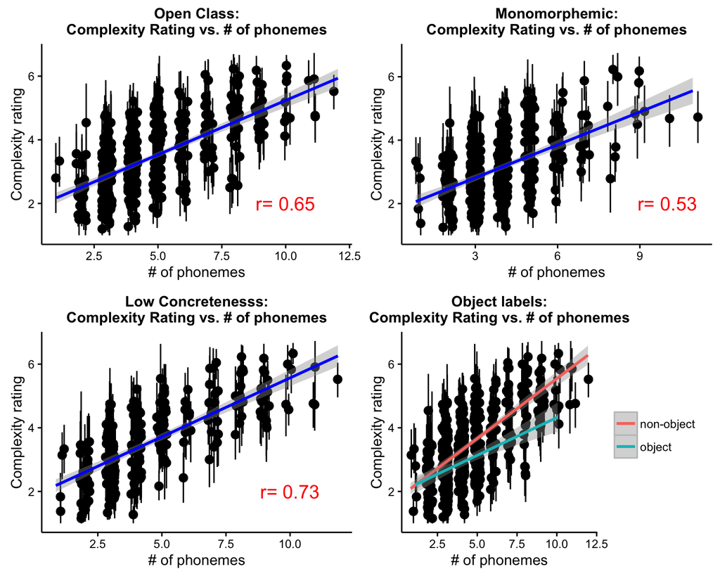

Complexity and length are intuitively related to a number of other psycholinguistic variables. We estimated concreteness, familiarity and imageability from the MRC corpus [3], and word frequency from a corpus of transcripts of American English movies (Subtlex-us database; [4]). All of these variables were reliably correlated with complexity (concreteness: *r* = -.27; familiarity: *r* = -.43; imageability: *r* = -.21; frequency: *r* = -.42, all *ps* <.0001). Length was also highly correlated with frequency (phonemes: *r* = -.53, *p* <.0001).

Nonetheless, the relationship between word length and complexity remained reliable controlling for all four of these factors. We created an additive linear model predicting word length in terms of phonemes with complexity, controlling for concreteness, imageability, familiarity, and frequency. Model parameters are presented below.

|  | Estimate | Std. Error | t value | Pr(>\|t\|) |
| --- | --- | --- | --- | --- |
| (Intercept) | 7.5020 | 0.2061 | 36.40 | 0.0000 |
| complexity | 0.2429 | 0.0116 | 20.86 | 0.0000 |
| mrc.fam | 0.0024 | 0.0005 | 4.80 | 0.0000 |
| mrc.imag | -0.0003 | 0.0004 | -0.81 | 0.4183 |
| mrc.conc | -0.0033 | 0.0004 | -9.16 | 0.0000 |
| subt.log.freq | -1.1556 | 0.0332 | -34.80 | 0.0000 |

This pattern held for the other two metrics of word length (morphemes and syllables).

Finally, we also looked at the relationship between length and complexity controling for surprisal (Piantadosi, et al., 2011) [5]. We used bigram surprisal values from the British National Corpus (BNC) [6]. As in Piantadosi et al. (2011), we use Spearman correlations. Below we plot the correlation coefficient between length in characters and other factors, indicated along the x-axis. The symbols on the plot show the correlation, partialing out one of the other factors (where the partialed factor is indicated by the shape of the symbol).

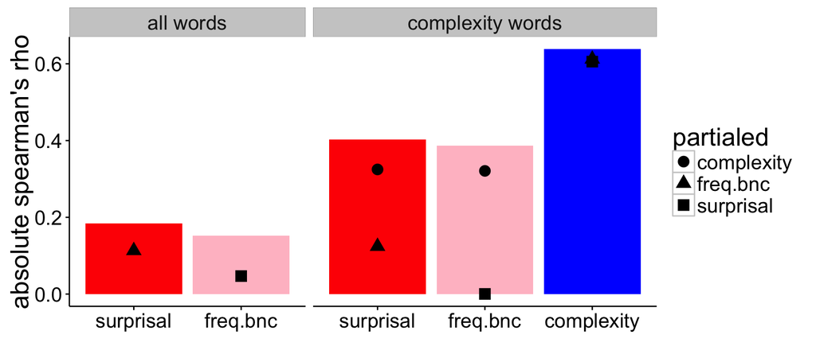

To examine the relative contributions of these three predictors, we constructed an additive linear model prediction word length with complexity, surprisal, and log frequency. Complexity and surprisal were reliable predictors of length, but log frequency was not. Model parameters are presented below.

|  | Estimate | Std. Error | t value | Pr(>\|t\|) |
| --- | --- | --- | --- | --- |
| (Intercept) | -2.0408 | 1.8898 | -1.08 | 0.2807 |
| complexity | 1.1077 | 0.0643 | 17.22 | 0.0000 |
| surprisal | 0.6599 | 0.2868 | 2.30 | 0.0218 |
| log.bnc.frequency | 0.0431 | 0.1108 | 0.39 | 0.6975 |

## Study 10: Cross-linguistic analysis

Native speakers evaluated the accuracy of these translations for 12 of the 79 languages. Native speakers were told to look at the translations provided by Google, and in cases where the translation was bad or not given, provide a “better translation.” Translations were not marked as inaccurate if the translation was missing. Plotted below is the proportion native speaker agreement with the Google translations across all 499 words. The dashed line indicates the mean across checked languages (*M* = .92).

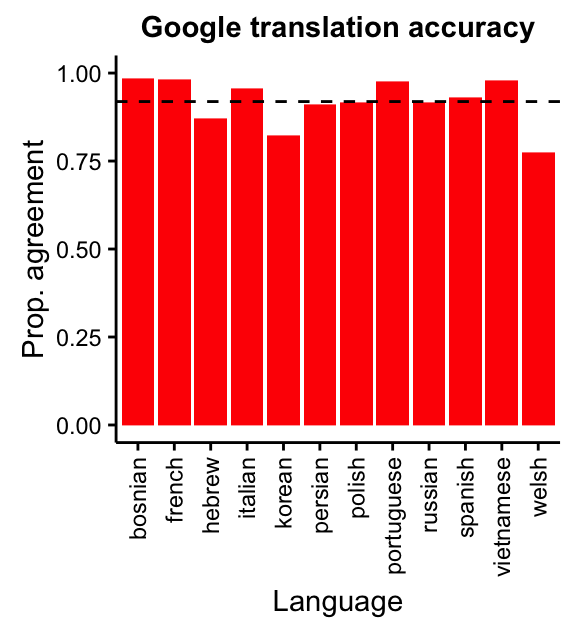

We counted the number of unicode characters for each translation. Variability in word length within languages was positively correlated with complexity ratings. Below the correlation coefficients are plotted for each language. Red bars indicate languages where the accuracy was checked by a native speaker and pink bars indicate unchecked languages. The dashed line indicates the grand mean correlation across languages. Triangles indicate the correlation between complexity and length, partialling out log spoken frequency in English. Circles indicate the correlation between complexity and length for the subset of words that are monomorphemic in English. Squares indicate the correlation between complexity and length for the subset of open class words.

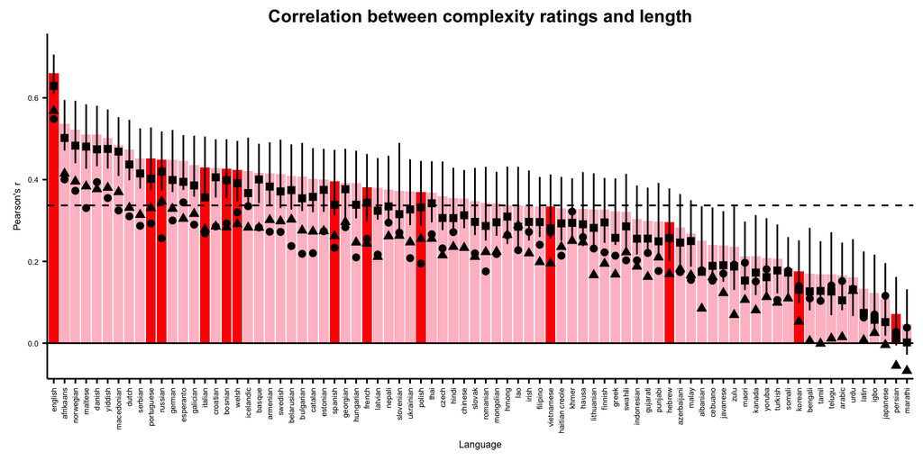

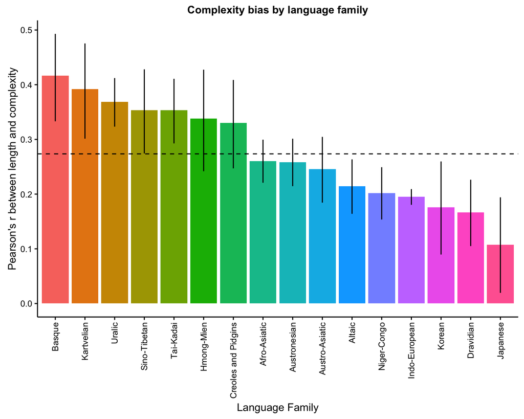

Following Jaeger, et al. (2011) [8], we included random intercepts and slopes by-family and by-native country. We built a model predicting length in terms of number of phonemes with complexity and frequency as fixed effects. The effect of complexity on length remained reliable in this model. Model parameters are presented below.

|  | full |
| --- | --- |
| Coefficients (Std. Error) |  |
| (Intercept) | 10.382 (2.028) |
| complexity | 0.699 (0.194) |
| subt.log.freq | -1.033 (0.244) |
| Variance components |  |
| (Intercept) $\|$ nativeCountry | 6.124 |
| complexity $\|$ nativeCountry | 0.475 |
| subt.log.freq $\|$ nativeCountry | 0.789 |
| (Intercept) $\|$ langFamily | 6.861 |
| complexity $\|$ langFamily | 0.672 |
| subt.log.freq $\|$ langFamily | 0.790 |
| Correlations |  |
| (Intercept) $\times$ complexity $\|$ nativeCountry | 0.106345 |
| (Intercept) $\times$ subt.log.freq $\|$ nativeCountry | -0.983593 |
| complexity $\times$ subt.log.freq $\|$ nativeCountry | 0.000945 |
| (Intercept) $\times$ complexity $\|$ langFamily | 0.832157 |
| (Intercept) $\times$ subt.log.freq $\|$ langFamily | -0.980593 |
| complexity $\times$ subt.log.freq $\|$ langFamily | -0.756049 |
| $\sigma$ | 5.59 |
| REML | 190464 |

## Study 11: Simultaneous frequency task

The task can be found [here](https://mllewis.github.io/projects/RC/experiment172/refcomplex172.html). Studies 11 and 12 are not reported in the paper.

Plotted below is the proportion of low frequency object selections as a function of language condition (long vs. short). Selections between the two conditions did not differ (χ2(1) = 0.02, p = .89).

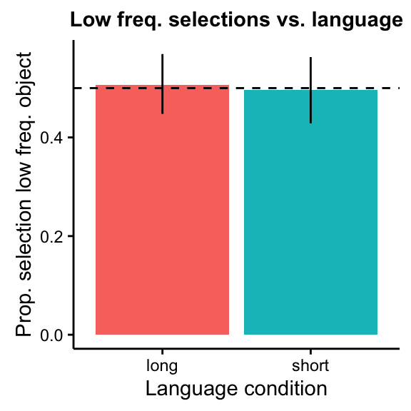

## Study 12: Sequential frequency task

The task can be found [here](https://mllewis.github.io/projects/RC/experiment16/refcomplex16.html).

In Study 12 (N = 97), we manipulated object frequency by sequentially presenting objects. Participants saw 60 objects from the set of normed real objects one at a time. One object was presented 10 times and a second object was presented 40 times. Ten additional objects were included as fillers. After this training phase, participants completed a single mapping trial as in Study 11. Word length was manipulated between participants.

Plotted below is the proportion of low frequency object selections as a function of language condition (long vs. short). Selections between the two conditions did not differ (χ2(1) = 0.01, p = .92).

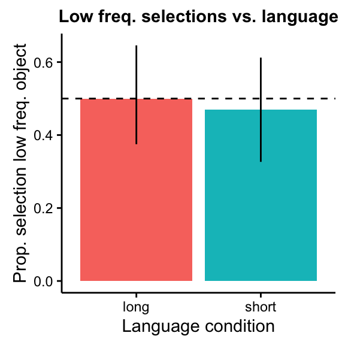

### References

[1] Crump, M., McDonnell, J., & Gureckis, T. (2013). Evaluating Amazon’s Mechanical Turk as a tool for experimental behavioral research. *PLoS ONE* **8**.

[2] Sanchez-Meca J., Marin-Martinez, F., & Chacon-Moscoso, S. (2003). Effect-size indices for dichotomized outcomes in meta-analysis. *Psychological Methods* **8**, 448-467.

[3] Wilson, M. (1988). MRC psycholinguistic database: Machine-usable dictionary, version 2.00. *Behavior Research Methods, Instruments, & Computers* **20**, 6–10.

[4] Brysbaert, M., & New, B. (2009). Moving beyond Kucera and Francis: A critical evaluation of current word frequency norms and the introduction of a new and improved word frequency measure for American English. *Behavior Research Methods* **41**, 977–990.

[5] Piantadosi, S., Tily, H., & Gibson, E. (2011b). Word lengths are optimized for efficient communication. *Proceedings of the National Academy of Sciences*, **108(9)**, 3526–3529.

[6] Clear J. (1993). The British National Corpus (MIT Press, Cambridge, MA).

[7] Haspelmath, M., Dryer, M. S., Gil, D., & Comrie, B. (2005). The world atlas of language structures.

[8] Jaeger, T. F., Graff, P., Croft, W., & Pontillo, D. (2011). Mixed effect models for genetic and areal dependencies in linguistic typology. *Linguistic Typology*, 15, 281–320.